# DSC_ITB

Untuk menghindari kerancuan (dan kadang juga bingung istilah istilahnya dalam Bahasa Indonesia tuh apa)  
Setiap comment di notebook ini akan menggunakan bahasa inggris

```python
import pandas as pd
import numpy as np
data = pd.read_csv('Downloads/DSC/train.csv')

#=========#
to_predict = pd.read_csv('Downloads/DSC/test.csv') #for submission
```

```python
#Taking a look at 10 data sample
data.sample(10)
```

|  | datetime | season | holiday | weekday | workingday | weather | temp | atemp | humidity | windspeed | casual | registered | cnt |
| --- | --- | --- | --- | --- | --- | --- | --- | --- | --- | --- | --- | --- | --- |
| 3377 | 2011-08-10 15:00:00 | 3 | 0 | 3 | 1 | 1 | 0.86 | 0.7424 | 0.30 | 0.3284 | 53 | 141 | 194 |
| 2522 | 2011-06-13 00:00:00 | 2 | 0 | 1 | 1 | 1 | 0.64 | 0.5909 | 0.78 | 0.1343 | 8 | 20 | 28 |
| 2934 | 2011-07-11 04:00:00 | 3 | 0 | 1 | 1 | 1 | 0.66 | 0.6212 | 0.74 | 0.2239 | 0 | 4 | 4 |
| 1094 | 2011-03-10 05:00:00 | 1 | 0 | 4 | 1 | 3 | 0.36 | 0.3485 | 0.00 | 0.1940 | 1 | 2 | 3 |
| 9655 | 2012-10-06 16:00:00 | 4 | 0 | 6 | 0 | 1 | 0.60 | 0.6212 | 0.43 | 0.5224 | 317 | 342 | 659 |
| 7676 | 2012-05-19 05:00:00 | 2 | 0 | 6 | 0 | 1 | 0.46 | 0.4545 | 0.67 | 0.0000 | 1 | 11 | 12 |
| 561 | 2011-02-06 13:00:00 | 1 | 0 | 0 | 0 | 1 | 0.34 | 0.3636 | 0.46 | 0.0000 | 47 | 135 | 182 |
| 3269 | 2011-08-06 03:00:00 | 3 | 0 | 6 | 0 | 2 | 0.66 | 0.6061 | 0.78 | 0.1642 | 14 | 28 | 42 |
| 6772 | 2012-03-19 11:00:00 | 1 | 0 | 1 | 1 | 1 | 0.56 | 0.5303 | 0.68 | 0.1642 | 56 | 145 | 201 |
| 1849 | 2011-05-03 23:00:00 | 2 | 0 | 2 | 1 | 2 | 0.56 | 0.5303 | 0.68 | 0.3284 | 12 | 50 | 62 |

There are row with windspeed value of 0, this could be a missing value  
but after checking the original repository : http://archive.ics.uci.edu/ml/datasets/Bike+Sharing+Dataset  
It is said that the windspeed value was already normalized, so we stop further suspicions

```python
#Checking for missing values
data.info()
```

```
<class 'pandas.core.frame.DataFrame'>
RangeIndex: 10886 entries, 0 to 10885
Data columns (total 13 columns):
datetime      10886 non-null object
season        10886 non-null int64
holiday       10886 non-null int64
weekday       10886 non-null int64
workingday    10886 non-null int64
weather       10886 non-null int64
temp          10886 non-null float64
atemp         10886 non-null float64
humidity      10886 non-null float64
windspeed     10886 non-null float64
casual        10886 non-null int64
registered    10886 non-null int64
cnt           10886 non-null int64
dtypes: float64(4), int64(8), object(1)
memory usage: 1.1+ MB
```

It looks like there are no missing values

```python
#Getting a sense of the distribution
data.describe(include='all')
```

|  | datetime | season | holiday | weekday | workingday | weather | temp | atemp | humidity | windspeed | casual | registered | cnt |
| --- | --- | --- | --- | --- | --- | --- | --- | --- | --- | --- | --- | --- | --- |
| count | 10886 | 10886.000000 | 10886.000000 | 10886.000000 | 10886.000000 | 10886.000000 | 10886.000000 | 10886.000000 | 10886.000000 | 10886.000000 | 10886.000000 | 10886.000000 | 10886.000000 |
| unique | 10886 | NaN | NaN | NaN | NaN | NaN | NaN | NaN | NaN | NaN | NaN | NaN | NaN |
| top | 2012-04-17 22:00:00 | NaN | NaN | NaN | NaN | NaN | NaN | NaN | NaN | NaN | NaN | NaN | NaN |
| freq | 1 | NaN | NaN | NaN | NaN | NaN | NaN | NaN | NaN | NaN | NaN | NaN | NaN |
| mean | NaN | 2.506614 | 0.028569 | 2.998622 | 0.680875 | 1.418427 | 0.493436 | 0.473102 | 0.618865 | 0.191036 | 36.021955 | 155.552177 | 191.574132 |
| std | NaN | 1.116174 | 0.166599 | 2.007770 | 0.466159 | 0.633839 | 0.190039 | 0.169492 | 0.192450 | 0.121859 | 49.960477 | 151.039033 | 181.144454 |
| min | NaN | 1.000000 | 0.000000 | 0.000000 | 0.000000 | 1.000000 | 0.020000 | 0.015200 | 0.000000 | 0.000000 | 0.000000 | 0.000000 | 1.000000 |
| 25% | NaN | 2.000000 | 0.000000 | 1.000000 | 0.000000 | 1.000000 | 0.340000 | 0.333300 | 0.470000 | 0.104500 | 4.000000 | 36.000000 | 42.000000 |
| 50% | NaN | 3.000000 | 0.000000 | 3.000000 | 1.000000 | 1.000000 | 0.500000 | 0.484800 | 0.620000 | 0.194000 | 17.000000 | 118.000000 | 145.000000 |
| 75% | NaN | 4.000000 | 0.000000 | 5.000000 | 1.000000 | 2.000000 | 0.640000 | 0.621200 | 0.770000 | 0.253700 | 49.000000 | 222.000000 | 284.000000 |
| max | NaN | 4.000000 | 1.000000 | 6.000000 | 1.000000 | 4.000000 | 1.000000 | 0.909100 | 1.000000 | 0.850700 | 367.000000 | 886.000000 | 977.000000 |

```python
#A Clearer Overview
import pandas_profiling
data.profile_report()
```

[interactive chart not shown]

```python
#Are there any holiday that classified as workingday?
data[(data['holiday']==1) & (data['workingday']==1)]
```

|  | datetime | season | holiday | weekday | workingday | weather | temp | atemp | humidity | windspeed | casual | registered | cnt |
| --- | --- | --- | --- | --- | --- | --- | --- | --- | --- | --- | --- | --- | --- |

```python
#convert to datetime
data['datetime'] = pd.to_datetime(data['datetime'])

#=========#
to_predict['datetime'] = pd.to_datetime(to_predict['datetime'])
```

```python
#Creating hour, month, and year variable
data['hour']=data['datetime'].apply(lambda x: x.hour)
data['month']=data['datetime'].apply(lambda x: x.month)
data['year']=data['datetime'].apply(lambda x: x.year)

#=========#
to_predict['hour']=to_predict['datetime'].apply(lambda x: x.hour)
to_predict['month']=to_predict['datetime'].apply(lambda x: x.month)
to_predict['year']=to_predict['datetime'].apply(lambda x: x.year)
```

```python
data.sample(5)
```

|  | datetime | season | holiday | weekday | workingday | weather | temp | atemp | humidity | windspeed | casual | registered | cnt | hour | month | year |
| --- | --- | --- | --- | --- | --- | --- | --- | --- | --- | --- | --- | --- | --- | --- | --- | --- |
| 5774 | 2012-01-15 18:00:00 | 1 | 0 | 0 | 0 | 1 | 0.18 | 0.1818 | 0.29 | 0.2239 | 7 | 113 | 120 | 18 | 1 | 2012 |
| 1311 | 2011-03-19 12:00:00 | 1 | 0 | 6 | 0 | 1 | 0.46 | 0.4545 | 0.33 | 0.4179 | 126 | 141 | 267 | 12 | 3 | 2011 |
| 9176 | 2012-09-05 17:00:00 | 3 | 0 | 3 | 1 | 1 | 0.76 | 0.7273 | 0.66 | 0.2537 | 83 | 780 | 863 | 17 | 9 | 2012 |
| 4180 | 2011-10-06 05:00:00 | 4 | 0 | 4 | 1 | 1 | 0.42 | 0.4242 | 0.62 | 0.1940 | 0 | 24 | 24 | 5 | 10 | 2011 |
| 5186 | 2011-12-10 04:00:00 | 4 | 0 | 6 | 0 | 2 | 0.26 | 0.2727 | 0.65 | 0.1045 | 0 | 3 | 3 | 4 | 12 | 2011 |

```python
#Checking the data types
data.dtypes
```

```
datetime      datetime64[ns]
season                 int64
holiday                int64
weekday                int64
workingday             int64
weather                int64
temp                 float64
atemp                float64
humidity             float64
windspeed            float64
casual                 int64
registered             int64
cnt                    int64
hour                   int64
month                  int64
year                   int64
dtype: object
```

```python
#Moving datetime variable to the index of the data
data = data.set_index('datetime')
```

```python
#Season, Holiday, Weekday, Workingday, Weather, Hour, Month, Year should be a Categorical Variable
categoryVariableList = ["hour","weekday","month","season","weather","holiday","workingday","year"]
for var in categoryVariableList:
    data[var] = data[var].astype("category")
    to_predict[var] = to_predict[var].astype("category")
```

```python
#Create a copy of the data, because we'll gonna map the categorical values with it's true label from the data repository
train = data.copy()
```

```python
#From the original repository : http://archive.ics.uci.edu/ml/datasets/Bike+Sharing+Dataset
data["season"] = data.season.map({1: "Spring", 2 : "Summer", 3 : "Fall", 4 :"Winter" })
data["weather"] = data.weather.map({1: " Clear + Few clouds + Partly cloudy + Partly cloudy",\
                                        2 : " Mist + Cloudy, Mist + Broken clouds, Mist + Few clouds, Mist ", \
                                        3 : " Light Snow, Light Rain + Thunderstorm + Scattered clouds, Light Rain + Scattered clouds", \
                                        4 :" Heavy Rain + Ice Pallets + Thunderstorm + Mist, Snow + Fog " })
data['weekday'] = data.weekday.map({0:'Sunday',1:'Monday',2:'Tuesday',3:'Wednesday',4:'Thursday',5:'Friday',6:'Saturday'})
```

```python
data.sample(5)
```

| datetime | season | holiday | weekday | workingday | weather | temp | atemp | humidity | windspeed | casual | registered | cnt | hour | month | year |
| --- | --- | --- | --- | --- | --- | --- | --- | --- | --- | --- | --- | --- | --- | --- | --- |
| 2011-01-01 00:00:00 | Spring | 0 | Saturday | 0 | Clear + Few clouds + Partly cloudy + Partly c... | 0.24 | 0.2879 | 0.81 | 0.0000 | 3 | 13 | 16 | 0 | 1 | 2011 |
| 2012-11-19 07:00:00 | Winter | 0 | Monday | 1 | Mist + Cloudy, Mist + Broken clouds, Mist + F... | 0.36 | 0.3333 | 0.66 | 0.2985 | 5 | 381 | 386 | 7 | 11 | 2012 |
| 2011-03-04 23:00:00 | Spring | 0 | Friday | 1 | Mist + Cloudy, Mist + Broken clouds, Mist + F... | 0.30 | 0.3030 | 0.75 | 0.1642 | 6 | 40 | 46 | 23 | 3 | 2011 |
| 2012-10-06 14:00:00 | Winter | 0 | Saturday | 0 | Mist + Cloudy, Mist + Broken clouds, Mist + F... | 0.60 | 0.6212 | 0.56 | 0.4179 | 269 | 307 | 576 | 14 | 10 | 2012 |
| 2011-01-15 04:00:00 | Spring | 0 | Saturday | 0 | Mist + Cloudy, Mist + Broken clouds, Mist + F... | 0.16 | 0.2273 | 0.59 | 0.0000 | 0 | 5 | 5 | 4 | 1 | 2011 |

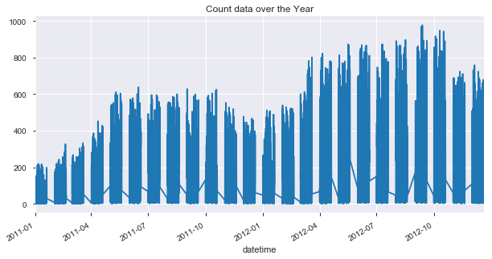

```python
import seaborn as sns
import matplotlib.pyplot as plt
plt.rcParams["figure.figsize"] = (10,5) #For larger plot
data.cnt.plot(title='Count data over the Year')
plt.show()
```

Findings: it looks like a bike user has grown from 2011 to 2012.  
The gaps between the month are caused by the latter date that of that month has been reserved on the 'test file'

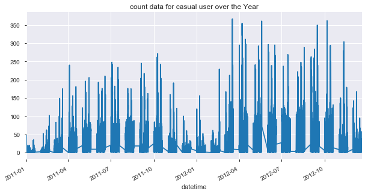

```python
data.casual.plot(title='count data for casual user over the Year')
plt.show()
```

Findings: The number of casual user have a significant drop on January each year. This could be caused by casual users have gone off on a holiday when compared to registered user that are usually are a commuting worker

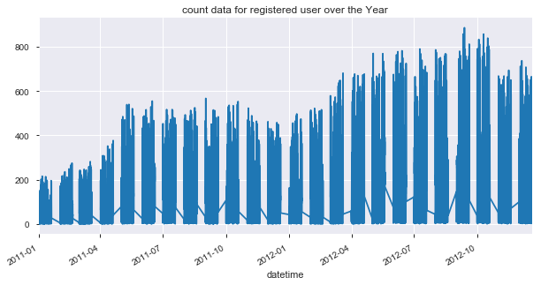

```python
data.registered.plot(title='count data for registered user over the Year')
plt.show()
```

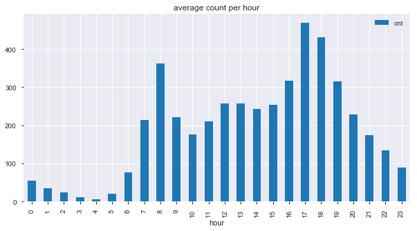

```python
#General Trend
data.groupby('hour').agg({'cnt':np.mean}).plot(kind='bar',title='average count per hour')
plt.show()
```

Findings  
There are a noticeable peak on 8 AM and 5-6 PM, this probably caused by commuting workers

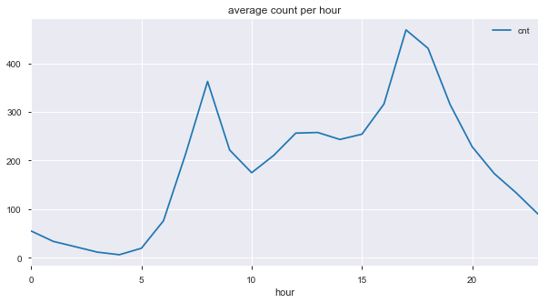

```python
#General Trend
#Alternative to a BarPlot to get a better grasp of the peak
data.groupby('hour').agg({'cnt':np.mean}).plot(kind='line',title='average count per hour')
```

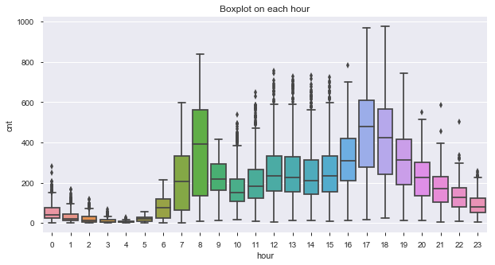

```python
#Boxplot of the count data based on hour (To get a sense of the distribution)
sns.boxplot(x=data.hour,y=data.cnt)
plt.title('Boxplot on each hour')
plt.show()
```

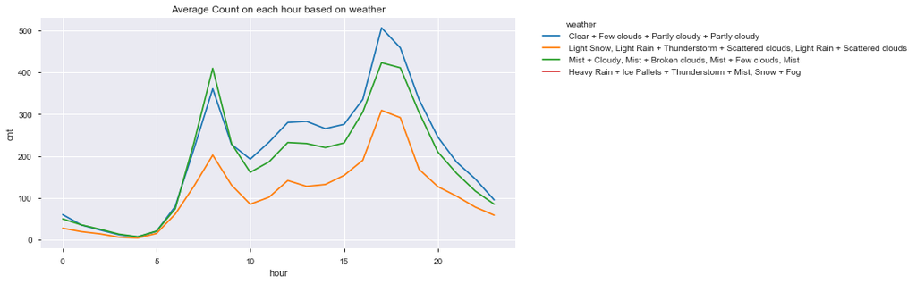

```python
#Average Count vs Weather by Hour
hour_by_weather = data.groupby(['hour','weather']).agg({'cnt':np.mean}).reset_index()
sns.lineplot(x=hour_by_weather.hour, y=hour_by_weather.cnt, hue = hour_by_weather.weather)
plt.title('Average Count on each hour based on weather')
plt.legend(bbox_to_anchor=(1.05, 1), loc=2, borderaxespad=0.) #So the legend will be outside the plot
plt.show()
```

Findings: it looks like there are a fewer average bike usage when the weather is bad, as expected  
(The orange line)

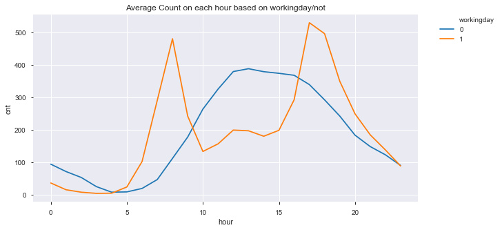

```python
#Average Count vs Workingday on each hour
hour_by_workingday = data.groupby(['hour','workingday']).agg({'cnt':np.mean}).reset_index()
sns.lineplot(x=hour_by_workingday.hour, y=hour_by_workingday.cnt, hue = hour_by_workingday.workingday)
plt.title('Average Count on each hour based on workingday/not')
plt.legend(bbox_to_anchor=(1.05, 1), loc=2, borderaxespad=0.)
```

Findings: on workingday there will be two peaks at the rush hour (7-8 AM and 5-6 PM)  
on the other hand, when on a dayoff, there will be less people renting the bike in the morning  
the peak on a dayoff happened at the afternoon

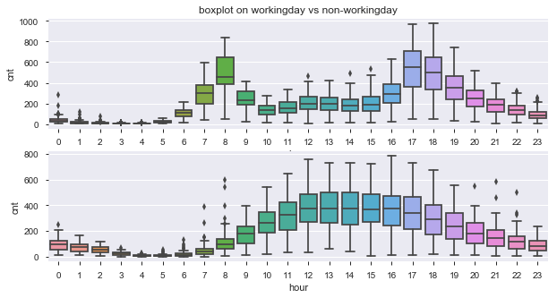

```python
#True distribution on each hour based on working day / not
plt.tight_layout
plt.subplot(2,1,1)
sns.boxplot(x=data[data['workingday']==1].hour,y=data[data['workingday']==1].cnt)
plt.title('boxplot on workingday vs non-workingday')
plt.subplot(2,1,2)
sns.boxplot(x=data[data['workingday']==0].hour,y=data[data['workingday']==0].cnt)
plt.show()
```

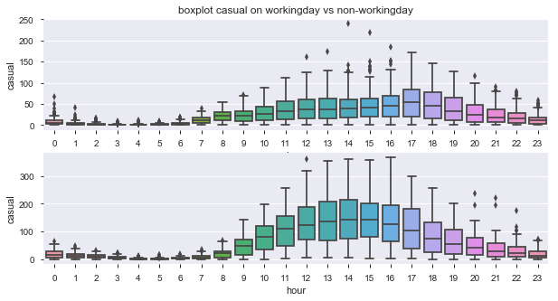

```python
plt.tight_layout
plt.subplot(2,1,1)
sns.boxplot(x=data[data['workingday']==1].hour,y=data[data['workingday']==1].casual)
plt.title('boxplot casual on workingday vs non-workingday')
plt.subplot(2,1,2)
sns.boxplot(x=data[data['workingday']==0].hour,y=data[data['workingday']==0].casual)
plt.show()
```

Findings: amount of casual users go up when on a day-off

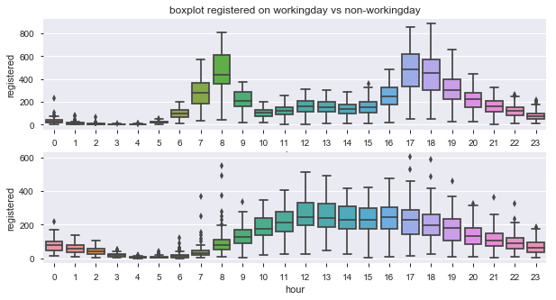

```python
plt.tight_layout
plt.subplot(2,1,1)
sns.boxplot(x=data[data['workingday']==1].hour,y=data[data['workingday']==1].registered)
plt.title('boxplot registered on workingday vs non-workingday')
plt.subplot(2,1,2)
sns.boxplot(x=data[data['workingday']==0].hour,y=data[data['workingday']==0].registered)
plt.show()
```

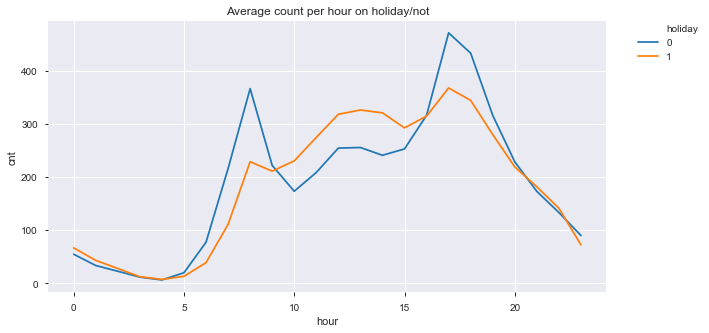

```python
#Average Count vs Holiday on each hour
hour_by_weather = data.groupby(['hour','holiday']).agg({'cnt':np.mean}).reset_index()
sns.lineplot(x=hour_by_weather.hour, y=hour_by_weather.cnt, hue = hour_by_weather.holiday)
plt.title('Average count per hour on holiday/not')
plt.legend(bbox_to_anchor=(1.05, 1), loc=2, borderaxespad=0.)
plt.show()
```

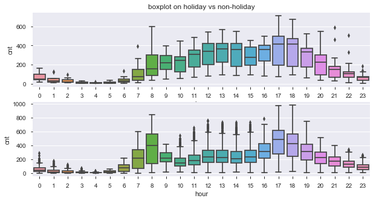

```python
plt.tight_layout
plt.subplot(2,1,1)
sns.boxplot(x=data[data['holiday']==1].hour,y=data[data['holiday']==1].cnt)
plt.title('boxplot on holiday vs non-holiday')
plt.subplot(2,1,2)
sns.boxplot(x=data[data['holiday']==0].hour,y=data[data['holiday']==0].cnt)
plt.show()
```

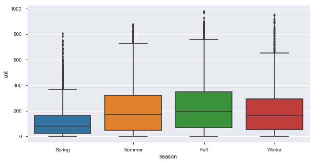

```python
sns.boxplot(data.season,data.cnt)
plt.show()
```

Findings: the amount of bike rental are relatively smaller on spring season

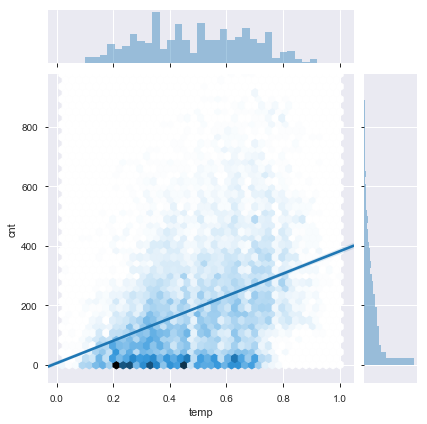

```python
g=sns.jointplot(data.temp,data.cnt,kind='hex')
sns.regplot(data.temp, data.cnt, ax=g.ax_joint, scatter=False)
plt.show()
```

Findings: there seems to be a weak upward trend between temp and count

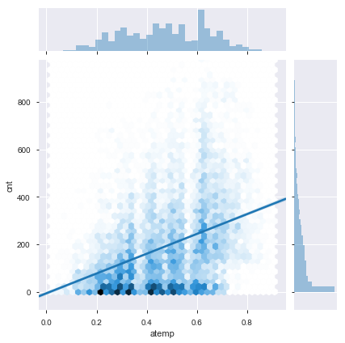

```python
g=sns.jointplot(data.atemp,data.cnt,kind='hex')
sns.regplot(data.atemp, data.cnt, ax=g.ax_joint, scatter=False)
```

Findings: there seems to be a weak upward trend between atemp and count

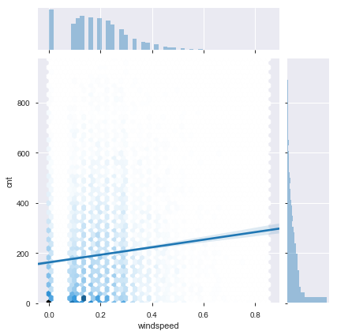

```python
g=sns.jointplot(data.windspeed,data.cnt,kind='hex')
sns.regplot(data.windspeed, data.cnt, ax=g.ax_joint, scatter=False)
```

Findings: there seems to be a very weak upward trend between windspeed and count

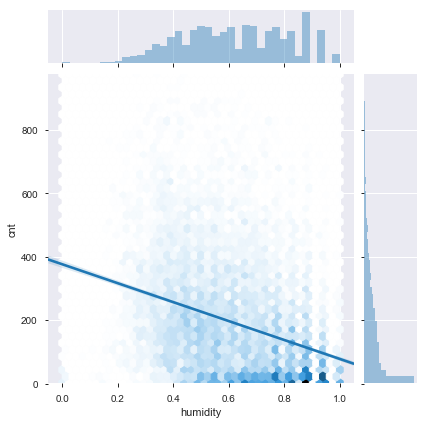

```python
g=sns.jointplot(data.humidity,data.cnt,kind='hex')
sns.regplot(data.humidity, data.cnt, ax=g.ax_joint, scatter=False)
```

Findings: there seems to be a weak downward trend between humidity and count

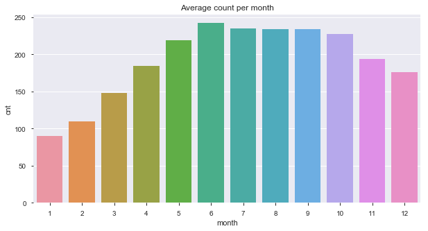

```python
avg_per_month = data.groupby('month').agg({'cnt':'mean'})
sns.barplot(x=avg_per_month.index,y=avg_per_month.cnt)
plt.title('Average count per month')
plt.show()
```

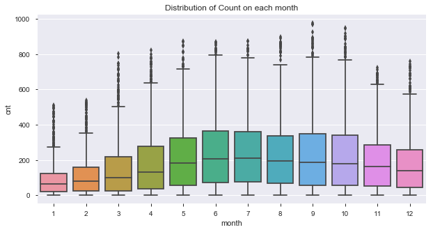

```python
sns.boxplot(x=data.month,y=data.cnt)
plt.title('Distribution of Count on each month')
plt.show()
```

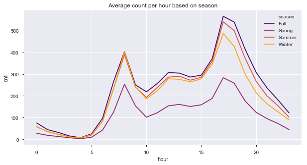

```python
avg_per_season = pd.DataFrame(data.groupby(['hour','season'],sort=True)['cnt'].mean()).reset_index()
sns.lineplot(x=avg_per_season.hour, y=avg_per_season.cnt,hue=avg_per_season.season,data=avg_per_season,palette='inferno')
plt.title('Average count per hour based on season')
plt.show()
```

Findings: spring season is the lowest

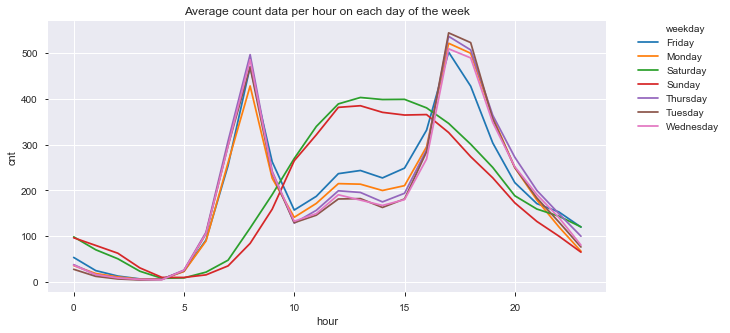

```python
per_weekday=data.groupby(['hour','weekday']).agg({'cnt':'mean'}).reset_index()
sns.lineplot(x=per_weekday.hour,y=per_weekday.cnt,hue=per_weekday.weekday)
plt.title('Average count data per hour on each day of the week')
plt.legend(bbox_to_anchor=(1.05, 1), loc=2, borderaxespad=0.)
plt.show()
```

=================================================== End of EDA ==================================================  
Start of Training data Preprocessing

Note: the train data is the one from train.csv, not from the result of sklearn train_test_split  
The result of the split (from the train.csv) will be named X_train and y_train

```python
labels = train.columns #Extracting the column names
```

```python
from sklearn.model_selection import train_test_split

# We'll drop the [Registered, Casual, Holiday] column (Because Holiday has already been represented by workingday)

X = train.reset_index().drop(['cnt','registered','casual','holiday'],axis=1).values #splitting the features and target variable
X_colnames = train.drop(['cnt','registered','casual','holiday'],axis=1).columns #Extracting the column names for later usage
y = train.reset_index().cnt.values

X_train, X_test, y_train, y_test = train_test_split(X, y, test_size=0.3, random_state=42)
```

=============================================== Feature Selection =============================================

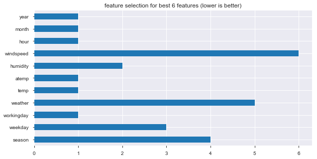

```python
#We'll use Recursive Feature Selection combined with Random Forest Regressor to determine the least significant variable
from sklearn.feature_selection import RFE
from sklearn.ensemble import RandomForestRegressor
rf_for_rfe = RandomForestRegressor(n_estimators=100,random_state=42) #We'll use 100 trees
selector = RFE(rf_for_rfe,6,step=1) #Selecting 6 best variable from a total of 11 variable,
#(the last 5 variable will be ranked from best candidate to worst)
selector.fit(X_train[:,1:],y_train)
rfe_ranking = pd.Series(selector.ranking_, index=X_colnames)
rfe_ranking.plot(kind='barh')
plt.title('feature selection for best 6 features (lower is better)')
plt.show()
```

Findings: windspeed are ranked lowest, this can be explained by the fact that people doesn't care that much about windspeed when riding a bike unless there is some unusually high windspeed

Conclusion : let's drop windspeed variable

```python
X = train.reset_index().drop(['cnt','registered','casual','holiday','windspeed'],axis=1).values
X_colnames = train.drop(['cnt','registered','casual','holiday','windspeed'],axis=1).columns
y = train.reset_index().cnt.values

X_train, X_test, y_train, y_test = train_test_split(X, y, test_size=0.3, random_state=42)
```

====================================== Start of Random Forest =======================================

```python
rf = RandomForestRegressor(n_estimators=100,random_state=42)
rf.fit(X_train[:,1:],y_train)

y_pred_rf = rf.predict(X_test[:,1:])
print('train score (Rsquared): ',rf.score(X_train[:,1:],y_train))
print('test score (Rsquared): ',rf.score(X_test[:,1:],y_test))
```

```
train score (Rsquared):  0.9924230041904541
test score (Rsquared):  0.9496144608318999
```

```python
from sklearn.metrics import mean_squared_log_error #Importing Mean Squared logaritmhic Error
print('RMSLE on train data :',np.sqrt(mean_squared_log_error(y_train,rf.predict(X_train[:,1:]))))
print('RMSLE on test data :',np.sqrt(mean_squared_log_error(y_test,y_pred_rf)))
```

```
RMSLE on train data : 0.15189943939144993
RMSLE on test data : 0.33130866123955555
```

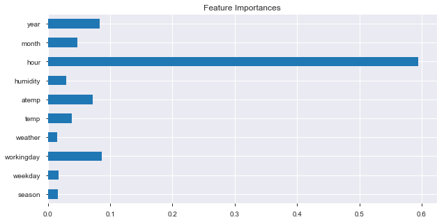

```python
feat_importances = pd.Series(rf.feature_importances_, index=X_colnames)
feat_importances.plot(kind='barh')
plt.title('Feature Importances')
plt.show()
```

Findings: the most important feature according to the Random Forest are hour, year, month, atemp, workingday

```python
train_result = train.copy() #To store the result
train_result.head()
```

| datetime | season | holiday | weekday | workingday | weather | temp | atemp | humidity | windspeed | casual | registered | cnt | hour | month | year |
| --- | --- | --- | --- | --- | --- | --- | --- | --- | --- | --- | --- | --- | --- | --- | --- |
| 2011-01-01 00:00:00 | 1 | 0 | 6 | 0 | 1 | 0.24 | 0.2879 | 0.81 | 0.0 | 3 | 13 | 16 | 0 | 1 | 2011 |
| 2011-01-01 01:00:00 | 1 | 0 | 6 | 0 | 1 | 0.22 | 0.2727 | 0.80 | 0.0 | 8 | 32 | 40 | 1 | 1 | 2011 |
| 2011-01-01 02:00:00 | 1 | 0 | 6 | 0 | 1 | 0.22 | 0.2727 | 0.80 | 0.0 | 5 | 27 | 32 | 2 | 1 | 2011 |
| 2011-01-01 03:00:00 | 1 | 0 | 6 | 0 | 1 | 0.24 | 0.2879 | 0.75 | 0.0 | 3 | 10 | 13 | 3 | 1 | 2011 |
| 2011-01-01 04:00:00 | 1 | 0 | 6 | 0 | 1 | 0.24 | 0.2879 | 0.75 | 0.0 | 0 | 1 | 1 | 4 | 1 | 2011 |

```python
train_result['pred_rf']=rf.predict(X[:,1:]) #Predict on the full 'train' dataset (the train.csv, not the one from splitting)
```

```python
train_result.sample(10)
```

| datetime | season | holiday | weekday | workingday | weather | temp | atemp | humidity | windspeed | casual | registered | cnt | hour | month | year | pred_rf |
| --- | --- | --- | --- | --- | --- | --- | --- | --- | --- | --- | --- | --- | --- | --- | --- | --- |
| 2012-03-07 23:00:00 | 1 | 0 | 3 | 1 | 1 | 0.44 | 0.4394 | 0.62 | 0.3284 | 4 | 58 | 62 | 23 | 3 | 2012 | 102.63 |
| 2012-03-01 16:00:00 | 1 | 0 | 4 | 1 | 1 | 0.58 | 0.5455 | 0.32 | 0.2985 | 38 | 323 | 361 | 16 | 3 | 2012 | 316.70 |
| 2012-05-14 03:00:00 | 2 | 0 | 1 | 1 | 2 | 0.58 | 0.5455 | 0.68 | 0.3284 | 0 | 2 | 2 | 3 | 5 | 2012 | 3.87 |
| 2011-12-15 05:00:00 | 4 | 0 | 4 | 1 | 2 | 0.32 | 0.3030 | 0.70 | 0.2836 | 0 | 24 | 24 | 5 | 12 | 2011 | 23.07 |
| 2012-05-13 23:00:00 | 2 | 0 | 0 | 0 | 2 | 0.62 | 0.6212 | 0.57 | 0.2239 | 17 | 57 | 74 | 23 | 5 | 2012 | 101.99 |
| 2012-09-10 16:00:00 | 3 | 0 | 1 | 1 | 1 | 0.66 | 0.6212 | 0.34 | 0.3284 | 108 | 380 | 488 | 16 | 9 | 2012 | 481.11 |
| 2011-02-08 00:00:00 | 1 | 0 | 2 | 1 | 2 | 0.28 | 0.3182 | 0.87 | 0.0000 | 4 | 6 | 10 | 0 | 2 | 2011 | 11.92 |
| 2012-05-06 13:00:00 | 2 | 0 | 0 | 0 | 2 | 0.60 | 0.6061 | 0.64 | 0.0000 | 197 | 368 | 565 | 13 | 5 | 2012 | 460.05 |
| 2011-12-18 02:00:00 | 4 | 0 | 0 | 0 | 1 | 0.22 | 0.2424 | 0.55 | 0.1045 | 2 | 39 | 41 | 2 | 12 | 2011 | 51.62 |
| 2012-07-09 18:00:00 | 3 | 0 | 1 | 1 | 1 | 0.76 | 0.6818 | 0.48 | 0.1343 | 82 | 790 | 872 | 18 | 7 | 2012 | 783.48 |

```python
#Resetting the index to preserve the column when melting the dataset for plotting purposes
train_copy=train_result.reset_index().copy()
```

```python
pred_rf_result = pd.melt(train_copy[['datetime',"cnt","pred_rf"]], id_vars=['datetime'], value_vars=['cnt', 'pred_rf']).set_index('datetime')
```

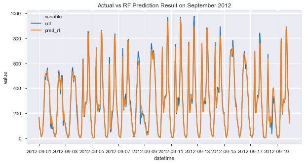

```python
#We'll compare the actual and prediction result on a small sample of data, September 2012
sns.lineplot(x=pred_rf_result['2012-09'].index, y=pred_rf_result['2012-09'].value, hue=pred_rf_result['2012-09'].variable)
plt.title('Actual vs RF Prediction Result on September 2012')
plt.show()
```

========================================= End of Random Forest =============================================

```python
train.sample(5)
```

| datetime | season | holiday | weekday | workingday | weather | temp | atemp | humidity | windspeed | casual | registered | cnt | hour | month | year |
| --- | --- | --- | --- | --- | --- | --- | --- | --- | --- | --- | --- | --- | --- | --- | --- |
| 2011-04-08 01:00:00 | 2 | 0 | 5 | 1 | 2 | 0.34 | 0.3333 | 0.76 | 0.1343 | 3 | 6 | 9 | 1 | 4 | 2011 |
| 2011-07-18 21:00:00 | 3 | 0 | 1 | 1 | 1 | 0.74 | 0.6970 | 0.66 | 0.1940 | 48 | 154 | 202 | 21 | 7 | 2011 |
| 2012-04-07 00:00:00 | 2 | 0 | 6 | 0 | 1 | 0.42 | 0.4242 | 0.26 | 0.2985 | 9 | 85 | 94 | 0 | 4 | 2012 |
| 2012-05-02 23:00:00 | 2 | 0 | 3 | 1 | 2 | 0.50 | 0.4848 | 0.77 | 0.2537 | 21 | 77 | 98 | 23 | 5 | 2012 |
| 2012-11-03 21:00:00 | 4 | 0 | 6 | 0 | 1 | 0.34 | 0.3485 | 0.53 | 0.1045 | 31 | 135 | 166 | 21 | 11 | 2012 |

Next we will use Poisson Regression, the input of Poisson Regression is a dataframe (unlike sklearn numpy array)  
So we'll rebuild the dataframe after the train_test_split

```python
#For Poisson
X_train_df = pd.DataFrame(X_train,columns=['datetime','season','weekday','workingday','weather','temp','atemp',
                                           'humidity','hour','month','year'])
y_train_df = pd.DataFrame(y_train,columns=['cnt'])
train_df = pd.concat([X_train_df,y_train_df],axis=1)
X_test_df = pd.DataFrame(X_test,columns=['datetime','season','weekday','workingday','weather','temp','atemp',
                                           'humidity','hour','month','year'])
y_test_df = pd.DataFrame(y_test,columns=['cnt'])
test_df = pd.concat([X_test_df,y_test_df],axis=1)
```

```python
train_df.dtypes
```

```
datetime      object
season        object
weekday       object
workingday    object
weather       object
temp          object
atemp         object
humidity      object
hour          object
month         object
year          object
cnt            int64
dtype: object
```

```python
#Almost all of the column has been converted to categorical, we'll revert ['temp','atemp','humidity'] back to numeric
numericVariableList = ["temp","atemp","humidity"]
for var in numericVariableList:
    train_df[var] = train_df[var].astype("float")
    test_df[var] = test_df[var].astype("float")
```

```python
train_df.sample(5)
```

|  | datetime | season | weekday | workingday | weather | temp | atemp | humidity | hour | month | year | cnt |
| --- | --- | --- | --- | --- | --- | --- | --- | --- | --- | --- | --- | --- |
| 587 | 2012-08-07 09:00:00 | 3 | 2 | 1 | 2 | 0.70 | 0.6667 | 0.74 | 9 | 8 | 2012 | 327 |
| 5907 | 2011-08-14 08:00:00 | 3 | 0 | 0 | 2 | 0.66 | 0.5909 | 0.89 | 8 | 8 | 2011 | 41 |
| 2431 | 2012-12-09 14:00:00 | 4 | 0 | 0 | 2 | 0.38 | 0.3939 | 0.87 | 14 | 12 | 2012 | 232 |
| 860 | 2011-07-15 03:00:00 | 3 | 5 | 1 | 1 | 0.60 | 0.5909 | 0.73 | 3 | 7 | 2011 | 7 |
| 7187 | 2012-05-07 21:00:00 | 2 | 1 | 1 | 2 | 0.54 | 0.5152 | 0.45 | 21 | 5 | 2012 | 247 |

=============================== Start of Poisson Regression ============================

```python
#Poisson Regression
from glm.glm import GLM
from glm.families import Poisson
import statsmodels.api as sm
import statsmodels.formula.api as smf
poisson = smf.glm(data=train_df,formula = 'cnt ~ season+weekday+weather+temp+atemp+humidity+hour+workingday+month+year', family = sm.families.Poisson(sm.families.links.log))
```

```python
poisson.fit().summary()
```

Generalized Linear Model Regression Results

| Dep. Variable: | cnt | No. Observations: | 7620 |
| --- | --- | --- | --- |
| Model: | GLM | Df Residuals: | 7571 |
| Model Family: | Poisson | Df Model: | 48 |
| Link Function: | log | Scale: | 1.0000 |
| Method: | IRLS | Log-Likelihood: | -1.4292e+05 |
| Date: | Sun, 25 Aug 2019 | Deviance: | 2.3714e+05 |
| Time: | 11:24:31 | Pearson chi2: | 2.32e+05 |
| No. Iterations: | 7 | Covariance Type: | nonrobust |

|  | coef | std err | z | P>\|z\| | [0.025 | 0.975] |
| --- | --- | --- | --- | --- | --- | --- |
| Intercept | 2.8338 | 0.010 | 281.972 | 0.000 | 2.814 | 2.853 |
| season[T.2] | 0.4430 | 0.004 | 102.104 | 0.000 | 0.435 | 0.452 |
| season[T.3] | 0.4338 | 0.005 | 84.892 | 0.000 | 0.424 | 0.444 |
| season[T.4] | 0.5247 | 0.004 | 140.514 | 0.000 | 0.517 | 0.532 |
| weekday[T.1] | 0.0463 | 0.006 | 8.387 | 0.000 | 0.036 | 0.057 |
| weekday[T.2] | 0.0506 | 0.006 | 8.128 | 0.000 | 0.038 | 0.063 |
| weekday[T.3] | 0.0530 | 0.006 | 8.689 | 0.000 | 0.041 | 0.065 |
| weekday[T.4] | 0.0798 | 0.006 | 12.910 | 0.000 | 0.068 | 0.092 |
| weekday[T.5] | 0.1039 | 0.006 | 17.048 | 0.000 | 0.092 | 0.116 |
| weekday[T.6] | 0.1081 | 0.003 | 34.255 | 0.000 | 0.102 | 0.114 |
| weather[T.2] | -0.0551 | 0.002 | -25.874 | 0.000 | -0.059 | -0.051 |
| weather[T.3] | -0.4470 | 0.004 | -105.721 | 0.000 | -0.455 | -0.439 |
| weather[T.4] | -0.2951 | 0.078 | -3.768 | 0.000 | -0.449 | -0.142 |
| hour[T.1] | -0.4728 | 0.012 | -38.058 | 0.000 | -0.497 | -0.448 |
| hour[T.2] | -0.7875 | 0.014 | -57.367 | 0.000 | -0.814 | -0.761 |
| hour[T.3] | -1.5216 | 0.018 | -83.523 | 0.000 | -1.557 | -1.486 |
| hour[T.4] | -2.0687 | 0.023 | -89.259 | 0.000 | -2.114 | -2.023 |
| hour[T.5] | -0.9178 | 0.014 | -63.848 | 0.000 | -0.946 | -0.890 |
| hour[T.6] | 0.4240 | 0.010 | 42.950 | 0.000 | 0.405 | 0.443 |
| hour[T.7] | 1.4483 | 0.009 | 170.285 | 0.000 | 1.432 | 1.465 |
| hour[T.8] | 1.9548 | 0.008 | 241.212 | 0.000 | 1.939 | 1.971 |
| hour[T.9] | 1.4080 | 0.008 | 166.527 | 0.000 | 1.391 | 1.425 |
| hour[T.10] | 1.1258 | 0.009 | 129.511 | 0.000 | 1.109 | 1.143 |
| hour[T.11] | 1.2954 | 0.009 | 151.174 | 0.000 | 1.279 | 1.312 |
| hour[T.12] | 1.4343 | 0.008 | 169.446 | 0.000 | 1.418 | 1.451 |
| hour[T.13] | 1.4538 | 0.008 | 171.379 | 0.000 | 1.437 | 1.470 |
| hour[T.14] | 1.3851 | 0.009 | 162.287 | 0.000 | 1.368 | 1.402 |
| hour[T.15] | 1.4044 | 0.009 | 165.043 | 0.000 | 1.388 | 1.421 |
| hour[T.16] | 1.6450 | 0.008 | 196.600 | 0.000 | 1.629 | 1.661 |
| hour[T.17] | 2.0498 | 0.008 | 252.478 | 0.000 | 2.034 | 2.066 |
| hour[T.18] | 2.0041 | 0.008 | 247.445 | 0.000 | 1.988 | 2.020 |
| hour[T.19] | 1.7025 | 0.008 | 206.283 | 0.000 | 1.686 | 1.719 |
| hour[T.20] | 1.3927 | 0.008 | 164.643 | 0.000 | 1.376 | 1.409 |
| hour[T.21] | 1.1331 | 0.009 | 129.558 | 0.000 | 1.116 | 1.150 |
| hour[T.22] | 0.9086 | 0.009 | 101.373 | 0.000 | 0.891 | 0.926 |
| hour[T.23] | 0.5267 | 0.010 | 55.061 | 0.000 | 0.508 | 0.545 |
| workingday[T.1] | 0.0066 | 0.005 | 1.227 | 0.220 | -0.004 | 0.017 |
| month[T.2] | 0.1914 | 0.006 | 33.199 | 0.000 | 0.180 | 0.203 |
| month[T.3] | 0.3320 | 0.006 | 57.826 | 0.000 | 0.321 | 0.343 |
| month[T.4] | 0.0647 | 0.003 | 23.910 | 0.000 | 0.059 | 0.070 |
| month[T.5] | 0.1976 | 0.003 | 74.200 | 0.000 | 0.192 | 0.203 |
| month[T.6] | 0.1807 | 0.003 | 58.860 | 0.000 | 0.175 | 0.187 |
| month[T.7] | 0.0750 | 0.003 | 24.634 | 0.000 | 0.069 | 0.081 |
| month[T.8] | 0.1400 | 0.003 | 49.218 | 0.000 | 0.134 | 0.146 |
| month[T.9] | 0.2188 | 0.003 | 85.141 | 0.000 | 0.214 | 0.224 |
| month[T.10] | 0.2508 | 0.003 | 84.760 | 0.000 | 0.245 | 0.257 |
| month[T.11] | 0.1553 | 0.003 | 60.675 | 0.000 | 0.150 | 0.160 |
| month[T.12] | 0.1185 | 0.003 | 43.770 | 0.000 | 0.113 | 0.124 |
| year[T.2012] | 0.4725 | 0.002 | 272.466 | 0.000 | 0.469 | 0.476 |
| temp | 0.1100 | 0.027 | 4.104 | 0.000 | 0.057 | 0.163 |
| atemp | 0.8680 | 0.028 | 31.447 | 0.000 | 0.814 | 0.922 |
| humidity | -0.2181 | 0.006 | -34.565 | 0.000 | -0.231 | -0.206 |

```python
y_pred_poisson=poisson.fit().predict(test_df)
```

```python
train_result['pred_poisson']=poisson.fit().predict(train)
```

```python
train_result.sample(10)
```

| datetime | season | holiday | weekday | workingday | weather | temp | atemp | humidity | windspeed | casual | registered | cnt | hour | month | year | pred_rf | pred_poisson |
| --- | --- | --- | --- | --- | --- | --- | --- | --- | --- | --- | --- | --- | --- | --- | --- | --- | --- |
| 2012-03-16 10:00:00 | 1 | 0 | 5 | 1 | 2 | 0.40 | 0.4091 | 0.87 | 0.0896 | 44 | 136 | 180 | 10 | 3 | 2012 | 161.05 | 152.735657 |
| 2012-10-02 14:00:00 | 4 | 0 | 2 | 1 | 3 | 0.60 | 0.5455 | 0.88 | 0.1343 | 16 | 147 | 163 | 14 | 10 | 2012 | 119.38 | 226.891155 |
| 2011-05-03 10:00:00 | 2 | 0 | 2 | 1 | 2 | 0.64 | 0.6061 | 0.69 | 0.3582 | 36 | 91 | 127 | 10 | 5 | 2011 | 132.64 | 155.753705 |
| 2012-03-07 20:00:00 | 1 | 0 | 3 | 1 | 1 | 0.50 | 0.4848 | 0.51 | 0.2537 | 18 | 242 | 260 | 20 | 3 | 2012 | 261.75 | 233.953361 |
| 2011-05-08 15:00:00 | 2 | 0 | 0 | 0 | 1 | 0.60 | 0.6212 | 0.49 | 0.0000 | 128 | 230 | 358 | 15 | 5 | 2011 | 363.88 | 216.403704 |
| 2011-10-15 03:00:00 | 4 | 0 | 6 | 0 | 1 | 0.44 | 0.4394 | 0.62 | 0.1940 | 5 | 18 | 23 | 3 | 10 | 2011 | 24.82 | 12.064862 |
| 2012-09-01 04:00:00 | 3 | 0 | 6 | 0 | 1 | 0.70 | 0.6515 | 0.70 | 0.0000 | 3 | 9 | 12 | 4 | 9 | 2012 | 12.14 | 12.038431 |
| 2011-04-15 07:00:00 | 2 | 1 | 5 | 0 | 1 | 0.40 | 0.4091 | 0.71 | 0.1642 | 10 | 139 | 149 | 7 | 4 | 2011 | 70.18 | 170.344879 |
| 2012-03-02 06:00:00 | 1 | 0 | 5 | 1 | 1 | 0.30 | 0.3333 | 0.70 | 0.0000 | 4 | 88 | 92 | 6 | 3 | 2012 | 90.66 | 76.883453 |
| 2011-03-01 07:00:00 | 1 | 0 | 2 | 1 | 1 | 0.20 | 0.1818 | 0.59 | 0.3284 | 2 | 105 | 107 | 7 | 3 | 2011 | 111.40 | 112.425510 |

```python
print('RMSLE of Poisson Regression on test data: ', np.sqrt(mean_squared_log_error(y_test,y_pred_poisson)))
```

```
RMSLE of Poisson Regression on test data:  0.6258670587153897
```

Be Wary that this is only the result of the base poisson regression model  
we haven't specified an interaction between variables  
(unlike Random Forest Model who could specify the interaction automatically) Further tuning of the formula should be considered

```python
train_copy=train_result.reset_index().copy() #For Plotting purposes
```

```python
pred_poisson_result = pd.melt(train_copy[['datetime',"cnt","pred_poisson"]], id_vars=['datetime'], value_vars=['cnt', 'pred_poisson']).set_index('datetime')
```

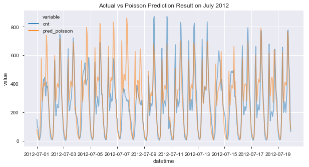

```python
sns.lineplot(x=pred_poisson_result['2012-07'].index, y=pred_poisson_result['2012-07'].value, hue=pred_poisson_result['2012-07'].variable,alpha=0.5)
plt.title('Actual vs Poisson Prediction Result on July 2012')
plt.show()
```

Findings: the prediction from base poisson model sometimes overestimate and underestimate the bike count data

======================================= End of Poisson Regression =========================================

========================================= Start of Random Forest Tuning ==========================================

```python
#Tuning the Random Forest
from sklearn.model_selection import GridSearchCV
no_of_test=[100,300,500] #From a selection of 100, 300, 500 trees
params_dict={'n_estimators':no_of_test,'n_jobs':[-1],'max_features':["auto",'sqrt','log2']}

#we will use Grid Search Cross Validation to test out several candidates of Parameters
cv_rf=GridSearchCV(estimator=RandomForestRegressor(),param_grid=params_dict,scoring='neg_mean_squared_log_error',
                    verbose=1,return_train_score=True, cv=5)

#The scoring used is negative mean quared log error because CV will maximize the result
#So by maximizing the negative mean squared log error, we'll get the minimum mean squared log error
cv_rf.fit(X_train[:,1:],y_train)
```

```
Fitting 5 folds for each of 9 candidates, totalling 45 fits
```

```
[Parallel(n_jobs=1)]: Using backend SequentialBackend with 1 concurrent workers.
[Parallel(n_jobs=1)]: Done  45 out of  45 | elapsed:  1.2min finished
```

```
GridSearchCV(cv=5, error_score='raise-deprecating',
       estimator=RandomForestRegressor(bootstrap=True, criterion='mse', max_depth=None,
           max_features='auto', max_leaf_nodes=None,
           min_impurity_decrease=0.0, min_impurity_split=None,
           min_samples_leaf=1, min_samples_split=2,
           min_weight_fraction_leaf=0.0, n_estimators='warn', n_jobs=None,
           oob_score=False, random_state=None, verbose=0, warm_start=False),
       fit_params=None, iid='warn', n_jobs=None,
       param_grid={'n_estimators': [100, 300, 500], 'n_jobs': [-1], 'max_features': ['auto', 'sqrt', 'log2']},
       pre_dispatch='2*n_jobs', refit=True, return_train_score=True,
       scoring='neg_mean_squared_log_error', verbose=1)
```

```python
cv_result=pd.DataFrame(cv_rf.cv_results_)
cv_result
```

|  | mean_fit_time | std_fit_time | mean_score_time | std_score_time | param_max_features | param_n_estimators | param_n_jobs | params | split0_test_score | split1_test_score | ... | mean_test_score | std_test_score | rank_test_score | split0_train_score | split1_train_score | split2_train_score | split3_train_score | split4_train_score | mean_train_score | std_train_score |
| --- | --- | --- | --- | --- | --- | --- | --- | --- | --- | --- | --- | --- | --- | --- | --- | --- | --- | --- | --- | --- | --- |
| 0 | 1.240224 | 1.372716 | 0.105617 | 0.000660 | auto | 100 | -1 | {'max_features': 'auto', 'n_estimators': 100, ... | -0.123238 | -0.111046 | ... | -0.118815 | 0.009693 | 3 | -0.024349 | -0.026749 | -0.023512 | -0.025553 | -0.024475 | -0.024928 | 0.001118 |
| 1 | 1.366510 | 0.019411 | 0.105189 | 0.000452 | auto | 300 | -1 | {'max_features': 'auto', 'n_estimators': 300, ... | -0.121666 | -0.111196 | ... | -0.118153 | 0.009713 | 2 | -0.024169 | -0.025079 | -0.023187 | -0.024648 | -0.024005 | -0.024218 | 0.000638 |
| 2 | 2.423283 | 0.215543 | 0.105758 | 0.001010 | auto | 500 | -1 | {'max_features': 'auto', 'n_estimators': 500, ... | -0.121209 | -0.111537 | ... | -0.117989 | 0.009020 | 1 | -0.024289 | -0.025385 | -0.022772 | -0.025184 | -0.023875 | -0.024301 | 0.000946 |
| 3 | 0.415042 | 0.031032 | 0.105462 | 0.000768 | sqrt | 100 | -1 | {'max_features': 'sqrt', 'n_estimators': 100, ... | -0.266950 | -0.231158 | ... | -0.246762 | 0.016759 | 9 | -0.063638 | -0.060336 | -0.060970 | -0.064112 | -0.065001 | -0.062811 | 0.001827 |
| 4 | 1.196310 | 0.048980 | 0.106771 | 0.001266 | sqrt | 300 | -1 | {'max_features': 'sqrt', 'n_estimators': 300, ... | -0.250769 | -0.226741 | ... | -0.235382 | 0.015188 | 6 | -0.058472 | -0.055879 | -0.060153 | -0.061124 | -0.058829 | -0.058891 | 0.001779 |
| 5 | 1.781585 | 0.163609 | 0.105707 | 0.000630 | sqrt | 500 | -1 | {'max_features': 'sqrt', 'n_estimators': 500, ... | -0.250019 | -0.230491 | ... | -0.235005 | 0.014081 | 4 | -0.057085 | -0.057296 | -0.057563 | -0.060338 | -0.059290 | -0.058314 | 0.001278 |
| 6 | 0.416905 | 0.010643 | 0.105581 | 0.000583 | log2 | 100 | -1 | {'max_features': 'log2', 'n_estimators': 100, ... | -0.249395 | -0.223189 | ... | -0.238794 | 0.013496 | 8 | -0.057444 | -0.059029 | -0.065733 | -0.064845 | -0.059561 | -0.061322 | 0.003325 |
| 7 | 1.036585 | 0.021433 | 0.105708 | 0.000636 | log2 | 300 | -1 | {'max_features': 'log2', 'n_estimators': 300, ... | -0.253960 | -0.239654 | ... | -0.235360 | 0.015993 | 5 | -0.056709 | -0.059345 | -0.059574 | -0.058535 | -0.056191 | -0.058071 | 0.001378 |
| 8 | 1.680867 | 0.145990 | 0.105192 | 0.000406 | log2 | 500 | -1 | {'max_features': 'log2', 'n_estimators': 500, ... | -0.252959 | -0.234537 | ... | -0.235666 | 0.013732 | 7 | -0.058820 | -0.058600 | -0.058927 | -0.060383 | -0.057734 | -0.058893 | 0.000855 |

9 rows × 23 columns

```python
cv_rf.best_estimator_ #the best parameter from our list of candidates
```

```
RandomForestRegressor(bootstrap=True, criterion='mse', max_depth=None,
           max_features='auto', max_leaf_nodes=None,
           min_impurity_decrease=0.0, min_impurity_split=None,
           min_samples_leaf=1, min_samples_split=2,
           min_weight_fraction_leaf=0.0, n_estimators=500, n_jobs=-1,
           oob_score=False, random_state=None, verbose=0, warm_start=False)
```

```python
cv_rf.scorer_
```

```
make_scorer(mean_squared_log_error, greater_is_better=False)
```

```python
print('best (negative) mean squared log error on cv: ',cv_rf.best_score_)
print('best RMSLE on cv: ',np.sqrt(-cv_rf.best_score_))
```

```
best (negative) mean squared log error on cv:  -0.11798886238118905
best RMSLE on cv:  0.34349506893285825
```

```python
y_pred_cv_rf = cv_rf.predict(X_test[:,1:])
```

```python
print('RMSLE on test set: ',np.sqrt(mean_squared_log_error(y_test,y_pred_cv_rf)))
```

```
RMSLE on test set:  0.33154603666628873
```

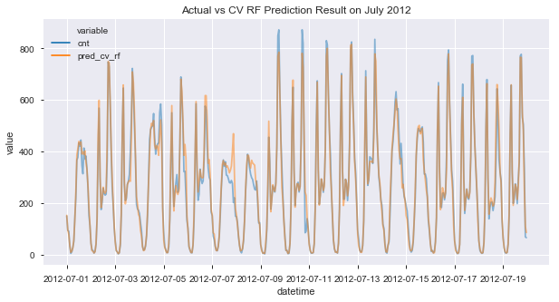

```python
#plotting the actual vs pred result on CV RF
train_result['pred_cv_rf']=cv_rf.predict(X[:,1:])
train_copy=train_result.reset_index().copy() #For Plotting purposes
pred_cv_rf_result = pd.melt(train_copy[['datetime',"cnt","pred_cv_rf"]], id_vars=['datetime'], value_vars=['cnt', 'pred_cv_rf']).set_index('datetime')

sns.lineplot(x=pred_cv_rf_result['2012-07'].index, y=pred_cv_rf_result['2012-07'].value, hue=pred_cv_rf_result['2012-07'].variable,alpha=0.5)

plt.title('Actual vs CV RF Prediction Result on July 2012')
plt.show()
```

========================================= Start of Neural Network ==========================================

```python
train.sample(5)
```

| datetime | season | holiday | weekday | workingday | weather | temp | atemp | humidity | windspeed | casual | registered | cnt | hour | month | year |
| --- | --- | --- | --- | --- | --- | --- | --- | --- | --- | --- | --- | --- | --- | --- | --- |
| 2011-04-18 02:00:00 | 2 | 0 | 1 | 1 | 1 | 0.42 | 0.4242 | 0.67 | 0.1045 | 14 | 2 | 16 | 2 | 4 | 2011 |
| 2011-05-14 20:00:00 | 2 | 0 | 6 | 0 | 3 | 0.54 | 0.5152 | 0.94 | 0.1343 | 42 | 115 | 157 | 20 | 5 | 2011 |
| 2012-08-13 17:00:00 | 3 | 0 | 1 | 1 | 1 | 0.80 | 0.7121 | 0.36 | 0.1642 | 102 | 716 | 818 | 17 | 8 | 2012 |
| 2011-05-16 12:00:00 | 2 | 0 | 1 | 1 | 1 | 0.66 | 0.6212 | 0.54 | 0.0896 | 72 | 137 | 209 | 12 | 5 | 2011 |
| 2012-02-15 22:00:00 | 1 | 0 | 3 | 1 | 1 | 0.34 | 0.3485 | 0.49 | 0.1045 | 3 | 104 | 107 | 22 | 2 | 2012 |

```python
#One-Hot Encoding the categorical Variable dataframe
season = pd.get_dummies(train['season'],prefix='season')
weekday = pd.get_dummies(train['weekday'],prefix='weekday')
weather = pd.get_dummies(train['weather'],prefix='weather')
hour = pd.get_dummies(train['hour'],prefix='hour')
month = pd.get_dummies(train['month'],prefix='month')
year = pd.get_dummies(train['year'],prefix='year')
train_encoded = pd.concat([season,train[['holiday']],weekday,train[['workingday']],weather,
           train[['temp','atemp','humidity','windspeed',
                  'casual','registered','cnt']],
           hour,month,year],axis=1)
```

```python
train_encoded.sample(5)
```

| datetime | season_1 | season_2 | season_3 | season_4 | holiday | weekday_0 | weekday_1 | weekday_2 | weekday_3 | weekday_4 | ... | month_5 | month_6 | month_7 | month_8 | month_9 | month_10 | month_11 | month_12 | year_2011 | year_2012 |
| --- | --- | --- | --- | --- | --- | --- | --- | --- | --- | --- | --- | --- | --- | --- | --- | --- | --- | --- | --- | --- | --- |
| 2011-06-08 17:00:00 | 0 | 1 | 0 | 0 | 0 | 0 | 0 | 0 | 1 | 0 | ... | 0 | 1 | 0 | 0 | 0 | 0 | 0 | 0 | 1 | 0 |
| 2012-01-02 18:00:00 | 1 | 0 | 0 | 0 | 1 | 0 | 1 | 0 | 0 | 0 | ... | 0 | 0 | 0 | 0 | 0 | 0 | 0 | 0 | 0 | 1 |
| 2011-06-14 03:00:00 | 0 | 1 | 0 | 0 | 0 | 0 | 0 | 1 | 0 | 0 | ... | 0 | 1 | 0 | 0 | 0 | 0 | 0 | 0 | 1 | 0 |
| 2012-08-11 10:00:00 | 0 | 0 | 1 | 0 | 0 | 0 | 0 | 0 | 0 | 0 | ... | 0 | 0 | 0 | 1 | 0 | 0 | 0 | 0 | 0 | 1 |
| 2011-11-13 04:00:00 | 0 | 0 | 0 | 1 | 0 | 1 | 0 | 0 | 0 | 0 | ... | 0 | 0 | 0 | 0 | 0 | 0 | 1 | 0 | 1 | 0 |

5 rows × 62 columns

```python
X_encoded = train_encoded.reset_index().drop(['cnt','registered','casual','holiday','windspeed'],axis=1).values
X_encoded_colnames = train_encoded.drop(['cnt','registered','casual','holiday','windspeed'],axis=1).columns
y_encoded = train_encoded.reset_index().cnt.values

X_encoded_train, X_encoded_test, y_encoded_train, y_encoded_test = train_test_split(X_encoded, y_encoded, test_size=0.3, random_state=42)
```

```python
import tensorflow as tf
from keras.layers import Dense
from keras.models import Sequential
from keras.callbacks import EarlyStopping
```

```python
model = Sequential()
monitor_val_acc = EarlyStopping(monitor='val_loss', patience=5) #Earlystopping based on val_loss with patience of 5 step
#First Hidden Layer with 200 nodes and 57 input nodes, relu activation
model.add(Dense(200,activation='relu',input_shape=(57,),kernel_initializer='normal'))

#Second Hidden Layer with 100 nodes, relu activation
model.add(Dense(100,activation='relu',kernel_initializer='normal'))

#Third Hidden Layer with 50 nodes, relu activation
model.add(Dense(50,activation='relu',kernel_initializer='normal'))

#Fourth Hidden Layer with 20 nodes, relu activation
model.add(Dense(20,activation='relu',kernel_initializer='normal'))

#Output layer, relu activation
model.add(Dense(1,activation='relu',kernel_initializer='normal'))

#Adam optimizer with mean squared logarithmic error losses
model.compile(optimizer='adam',loss='msle')
```

```python
model.summary() #Neural Network Structure
```

```
_________________________________________________________________
Layer (type)                 Output Shape              Param #
=================================================================
dense_11 (Dense)             (None, 200)               11600
_________________________________________________________________
dense_12 (Dense)             (None, 100)               20100
_________________________________________________________________
dense_13 (Dense)             (None, 50)                5050
_________________________________________________________________
dense_14 (Dense)             (None, 20)                1020
_________________________________________________________________
dense_15 (Dense)             (None, 1)                 21
=================================================================
Total params: 37,791
Trainable params: 37,791
Non-trainable params: 0
_________________________________________________________________
```

```python
#100 epochs, with a validation split (splitted from the X_train), with an early stopping callbacks
model.fit(X_encoded_train[:,1:],y_encoded_train,epochs=100,verbose=1,validation_split=0.3,callbacks=[monitor_val_acc])
```

```
Train on 5334 samples, validate on 2286 samples
```

```
<keras.callbacks.History at 0x21068d027f0>
```

```python
print('Neural Network RMSLE on test data \n',np.sqrt(mean_squared_log_error(y_encoded_test,model.predict(X_encoded_test[:,1:]))))
```

```
Neural Network RMSLE on test data
 0.33111760115414945
```

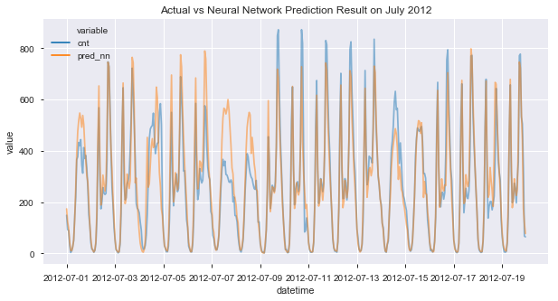

```python
#plotting the actual vs pred result on Neural Network
train_result['pred_nn']=model.predict(X_encoded[:,1:])
train_copy=train_result.reset_index().copy() #For Plotting purposes
pred_nn_result = pd.melt(train_copy[['datetime',"cnt","pred_nn"]], id_vars=['datetime'], value_vars=['cnt', 'pred_nn']).set_index('datetime')

sns.lineplot(x=pred_nn_result['2012-07'].index, y=pred_nn_result['2012-07'].value, hue=pred_nn_result['2012-07'].variable,alpha=0.5)

plt.title('Actual vs Neural Network Prediction Result on July 2012')
plt.show()
```

```python
train_result.sample(10)
```

| datetime | season | holiday | weekday | workingday | weather | temp | atemp | humidity | windspeed | casual | registered | cnt | hour | month | year | pred_rf | pred_poisson | pred_cv_rf | pred_nn |
| --- | --- | --- | --- | --- | --- | --- | --- | --- | --- | --- | --- | --- | --- | --- | --- | --- | --- | --- | --- |
| 2012-03-19 15:00:00 | 1 | 0 | 1 | 1 | 1 | 0.64 | 0.6212 | 0.57 | 0.2239 | 97 | 189 | 286 | 15 | 3 | 2012 | 268.83 | 265.285973 | 270.092 | 236.612579 |
| 2011-04-03 23:00:00 | 2 | 0 | 0 | 0 | 1 | 0.40 | 0.4091 | 0.50 | 0.0896 | 9 | 22 | 31 | 23 | 4 | 2011 | 35.07 | 63.953987 | 36.970 | 56.001873 |
| 2012-09-12 16:00:00 | 3 | 0 | 3 | 1 | 1 | 0.72 | 0.6515 | 0.37 | 0.1642 | 90 | 419 | 509 | 16 | 9 | 2012 | 488.38 | 506.525449 | 483.642 | 523.049255 |
| 2011-06-02 08:00:00 | 2 | 0 | 4 | 1 | 1 | 0.70 | 0.6364 | 0.32 | 0.2985 | 25 | 442 | 467 | 8 | 6 | 2011 | 456.88 | 427.613905 | 460.978 | 545.527039 |
| 2011-04-18 00:00:00 | 2 | 0 | 1 | 1 | 1 | 0.46 | 0.4545 | 0.47 | 0.0896 | 15 | 24 | 39 | 0 | 4 | 2011 | 80.23 | 41.970129 | 77.750 | 24.401495 |
| 2012-09-13 19:00:00 | 3 | 0 | 4 | 1 | 1 | 0.64 | 0.6061 | 0.65 | 0.1343 | 80 | 594 | 674 | 19 | 9 | 2012 | 572.97 | 493.962719 | 568.874 | 534.235413 |
| 2011-05-14 07:00:00 | 2 | 0 | 6 | 0 | 3 | 0.48 | 0.4697 | 1.00 | 0.0000 | 4 | 28 | 32 | 7 | 5 | 2011 | 63.98 | 124.723932 | 62.776 | 34.248192 |
| 2011-02-07 16:00:00 | 1 | 0 | 1 | 1 | 2 | 0.36 | 0.3485 | 0.57 | 0.1343 | 16 | 98 | 114 | 16 | 2 | 2011 | 109.02 | 132.387292 | 111.374 | 114.078377 |
| 2011-01-07 22:00:00 | 1 | 0 | 5 | 1 | 2 | 0.18 | 0.1970 | 0.43 | 0.1642 | 2 | 34 | 36 | 22 | 1 | 2011 | 38.75 | 49.138698 | 37.882 | 48.031261 |
| 2011-05-13 18:00:00 | 2 | 0 | 5 | 1 | 3 | 0.52 | 0.5000 | 0.88 | 0.1642 | 39 | 359 | 398 | 18 | 5 | 2011 | 336.54 | 230.725685 | 350.200 | 264.912109 |

```python
print('Neural Network RMSLE on train data: ',np.sqrt(mean_squared_log_error(y_encoded_train,model.predict(X_encoded_train[:,1:]))),
      '\nNeural Network RMSLE on test data: ',np.sqrt(mean_squared_log_error(y_encoded_test,model.predict(X_encoded_test[:,1:]))))
print('Random Forest RMSLE on train data: ',np.sqrt(mean_squared_log_error(y_train,rf.predict(X_train[:,1:]))),
      '\nRandom Forest RMSLE on test data: ',np.sqrt(mean_squared_log_error(y_test,rf.predict(X_test[:,1:]))))
print('CV Random Forest RMSLE on train data: ',np.sqrt(mean_squared_log_error(y_train,cv_rf.predict(X_train[:,1:]))),
      '\nCV Random Forest RMSLE on test data: ',np.sqrt(mean_squared_log_error(y_test,cv_rf.predict(X_test[:,1:]))))
print('Poisson Regression RMSLE on train data: ',np.sqrt(mean_squared_log_error(y_train,poisson.fit().predict(train_df))),
      '\nPoisson Regression RMSLE on test data: ',np.sqrt(mean_squared_log_error(y_test,poisson.fit().predict(test_df))))
```

```
Neural Network RMSLE on train data:  0.2684921599555393
Neural Network RMSLE on test data:  0.33111760115414945
Random Forest RMSLE on train data:  0.15189943939144993
Random Forest RMSLE on test data:  0.33130866123955555
CV Random Forest RMSLE on train data:  0.1499973681435013
CV Random Forest RMSLE on test data:  0.33154603666628873
Poisson Regression RMSLE on train data:  0.6185434249613425
Poisson Regression RMSLE on test data:  0.6258670587153897
```

```python
to_predict.sample(5)
```

|  | datetime | season | holiday | weekday | workingday | weather | temp | atemp | humidity | windspeed | hour | month | year |
| --- | --- | --- | --- | --- | --- | --- | --- | --- | --- | --- | --- | --- | --- |
| 2010 | 2011-08-26 18:00:00 | 3 | 0 | 5 | 1 | 2 | 0.74 | 0.7121 | 0.74 | 0.1343 | 18 | 8 | 2011 |
| 2231 | 2011-09-24 12:00:00 | 4 | 0 | 6 | 0 | 2 | 0.62 | 0.5758 | 0.83 | 0.0896 | 12 | 9 | 2011 |
| 1991 | 2011-08-25 23:00:00 | 3 | 0 | 4 | 1 | 1 | 0.62 | 0.5758 | 0.83 | 0.0896 | 23 | 8 | 2011 |
| 2488 | 2011-10-24 05:00:00 | 4 | 0 | 1 | 1 | 1 | 0.38 | 0.3939 | 0.87 | 0.0000 | 5 | 10 | 2011 |
| 1223 | 2011-05-28 23:00:00 | 2 | 0 | 6 | 0 | 1 | 0.64 | 0.5758 | 0.83 | 0.1940 | 23 | 5 | 2011 |

```python
#Submission
#==========#
to_predict_X = to_predict.drop(['holiday','windspeed'],axis=1).values
count = cv_rf.predict(to_predict_X[:,1:])
```

```python
submission = pd.DataFrame({'datetime':to_predict.datetime,'count':count})
submission.head(24)
```

|  | datetime | count |
| --- | --- | --- |
| 0 | 2011-01-20 00:00:00 | 12.134 |
| 1 | 2011-01-20 01:00:00 | 4.708 |
| 2 | 2011-01-20 02:00:00 | 3.530 |
| 3 | 2011-01-20 03:00:00 | 3.504 |
| 4 | 2011-01-20 04:00:00 | 3.150 |
| 5 | 2011-01-20 05:00:00 | 7.174 |
| 6 | 2011-01-20 06:00:00 | 35.586 |
| 7 | 2011-01-20 07:00:00 | 96.474 |
| 8 | 2011-01-20 08:00:00 | 206.172 |
| 9 | 2011-01-20 09:00:00 | 119.968 |
| 10 | 2011-01-20 10:00:00 | 57.812 |
| 11 | 2011-01-20 11:00:00 | 58.982 |
| 12 | 2011-01-20 12:00:00 | 77.208 |
| 13 | 2011-01-20 13:00:00 | 70.506 |
| 14 | 2011-01-20 14:00:00 | 73.512 |
| 15 | 2011-01-20 15:00:00 | 81.392 |
| 16 | 2011-01-20 16:00:00 | 89.366 |
| 17 | 2011-01-20 17:00:00 | 187.422 |
| 18 | 2011-01-20 18:00:00 | 170.678 |
| 19 | 2011-01-20 19:00:00 | 103.640 |
| 20 | 2011-01-20 20:00:00 | 73.440 |
| 21 | 2011-01-20 21:00:00 | 45.820 |
| 22 | 2011-01-20 22:00:00 | 43.388 |
| 23 | 2011-01-20 23:00:00 | 24.294 |

```python
submission.to_csv('submission.csv',index=False)
```